# Project: European migrant death

Data source: https://raw.githubusercontent.com/ondata/the-list/master/data/refugeesAndMigrants.csv

Project created by : Biplav Acharya

Date created: 10/28/2018 Last updated: 11/04/2018

Load the reqired package

```r
library(readr)
library(ggplot2)
library(gridExtra)
```

import the data

```r
EU_migration_deaths <- read_csv("https://raw.githubusercontent.com/ondata/the-list/master/data/refugeesAndMigrants.csv")
```

# Data management:

Compile the year of incident:

```r
EU_migration_deaths <- EU_migration_deaths[!is.na(nchar(EU_migration_deaths$`found dead`)),]
EU_migration_deaths$year <- EU_migration_deaths$`found dead`
for (i in 1:dim(EU_migration_deaths)[1]) {
  l <- nchar(EU_migration_deaths$year[i])
  if (l == 8) {
    EU_migration_deaths$year[i] <- substr(EU_migration_deaths$year[i],7,8)
  } else if (nchar(EU_migration_deaths$year[i]) == 6) {
    EU_migration_deaths$year[i] <- substr(EU_migration_deaths$year[i],5,6)
  }
}
for (i in 1:dim(EU_migration_deaths)[1]) {
  l <- nchar(EU_migration_deaths$year[i])
  if (l != 2) {
    EU_migration_deaths$year[i] <- substr(EU_migration_deaths$year[i],l-1,l)
  }
}
EU_migration_deaths$year <- as.numeric(as.character(EU_migration_deaths$year))
for (i in 1:dim(EU_migration_deaths)[1]) {
  if (EU_migration_deaths$year[i] < 20){
    EU_migration_deaths$year[i]<- EU_migration_deaths$year[i]+2000
  } else if (EU_migration_deaths$year[i] > 20) {
    EU_migration_deaths$year[i]<- EU_migration_deaths$year[i]+1900
  }
}
EU_migration_deaths$year[i] <- as.character(EU_migration_deaths$year[i])
```

Compile the Region of origin

```r
for (i in 1:length(EU_migration_deaths$`region of origin`)) {
  if (grepl(",",EU_migration_deaths$`region of origin`[i])|
      grepl("or ",EU_migration_deaths$`region of origin`[i])){
      EU_migration_deaths$`region of origin`[i] <- "unknown"
      }
}
```

Compile the path of migrant

```r
EU_migration_deaths$Path <- as.character(paste (EU_migration_deaths$`region of origin`, "to", EU_migration_deaths$`country of incident`))
```

Complile the cause of death

```r
EU_migration_deaths$`Nature of death` <- "other"
cof <- c(strsplit(EU_migration_deaths$`cause of death`, " "))

for (i in 1:dim(EU_migration_deaths)[1]) {
    if (grepl("presumed drowned",EU_migration_deaths$`cause of death`[i])) {
      EU_migration_deaths$`Nature of death`[i] <- "Presumed drowned"
      } else if (grepl("drown",EU_migration_deaths$`cause of death`[i])) {
        EU_migration_deaths$`Nature of death`[i] <- "Drown"
      } else if (grepl("bodies recovered",EU_migration_deaths$`cause of death`[i])) {
        EU_migration_deaths$`Nature of death`[i] <- "Bodies Recovered"
      } else if (grepl("mine",EU_migration_deaths$`cause of death`[i])) {
        EU_migration_deaths$`Nature of death`[i] <- "Mine field"
      } else if (grepl("suffoc",EU_migration_deaths$`cause of death`[i])) {
        EU_migration_deaths$`Nature of death`[i] <- "Suffocation"
      } else if (grepl("suicide",EU_migration_deaths$`cause of death`[i])) {
        EU_migration_deaths$`Nature of death`[i] <- "Suicide"
      } else if ((grepl("hunger",EU_migration_deaths$`cause of death`[i]))|
                  (grepl("starvation",EU_migration_deaths$`cause of death`[i]))|
                 (grepl("food",EU_migration_deaths$`cause of death`[i]))){
        EU_migration_deaths$`Nature of death`[i] <- "Hunger"
      } else if ((grepl("neglect",EU_migration_deaths$`cause of death`[i]))|
                 (grepl("abandon",EU_migration_deaths$`cause of death`[i]))|
                 (grepl("abandoned",EU_migration_deaths$`cause of death`[i]))){
        EU_migration_deaths$`Nature of death`[i] <- "Abandoned"
      }else if ((grepl("medical",EU_migration_deaths$`cause of death`[i]))|
                 (grepl("hospital",EU_migration_deaths$`cause of death`[i]))|
                 (grepl("cancer",EU_migration_deaths$`cause of death`[i]))|
                 (grepl("cardio",EU_migration_deaths$`cause of death`[i]))|
                 (grepl("heart",EU_migration_deaths$`cause of death`[i]))|
                 (grepl("cancer",EU_migration_deaths$`cause of death`[i]))|
                 (grepl("cardio",EU_migration_deaths$`cause of death`[i]))|
                 (grepl("heart",EU_migration_deaths$`cause of death`[i]))|
                 (grepl("hypothermia",EU_migration_deaths$`cause of death`[i]))|
                 (grepl("stroke",EU_migration_deaths$`cause of death`[i]))|
                 (grepl("wound",EU_migration_deaths$`cause of death`[i]))|
                 (grepl("neumonia",EU_migration_deaths$`cause of death`[i]))|
                 (grepl("pulmonary",EU_migration_deaths$`cause of death`[i]))|
                 (grepl("tuberculosis",EU_migration_deaths$`cause of death`[i]))|
                 (grepl("fever",EU_migration_deaths$`cause of death`[i]))|
                 (grepl("ill",EU_migration_deaths$`cause of death`[i]))|
                 (grepl("asphyxia",EU_migration_deaths$`cause of death`[i]))|
                 (grepl("clinic",EU_migration_deaths$`cause of death`[i]))|
                 (grepl("doctor",EU_migration_deaths$`cause of death`[i]))|
                 (grepl("hypothermia",EU_migration_deaths$`cause of death`[i]))){
        EU_migration_deaths$`Nature of death`[i] <- "Medical"
      } else if (grepl("fire",EU_migration_deaths$`cause of death`[i])) {
        EU_migration_deaths$`Nature of death`[i] <- "Fire"
      } else if (grepl("burn",EU_migration_deaths$`cause of death`[i])) {
        EU_migration_deaths$`Nature of death`[i] <- "Fire"
      } else if (grepl("arson",EU_migration_deaths$`cause of death`[i])) {
        EU_migration_deaths$`Nature of death`[i] <- "Arson"
      } else if (grepl("dehydration",EU_migration_deaths$`cause of death`[i])) {
        EU_migration_deaths$`Nature of death`[i] <- "Dehydration"
      } else if (grepl("murder",EU_migration_deaths$`cause of death`[i])) {
        EU_migration_deaths$`Nature of death`[i] <- "Murder"
      } else if (grepl("shot",EU_migration_deaths$`cause of death`[i])) {
        EU_migration_deaths$`Nature of death`[i] <- "Shot"
      } else if (grepl("detention",EU_migration_deaths$`cause of death`[i])) {
        EU_migration_deaths$`Nature of death`[i] <- "Detention"
      } else if (grepl("found dead",EU_migration_deaths$`cause of death`[i])) {
        EU_migration_deaths$`Nature of death`[i] <- "Found dead"
      } else if (grepl("missing",EU_migration_deaths$`cause of death`[i])) {
        EU_migration_deaths$`Nature of death`[i] <- "Missing"
      } else if (grepl("found",EU_migration_deaths$`cause of death`[i])) {
        EU_migration_deaths$`Nature of death`[i] <- "Found dead"
      } else if (grepl("tortured",EU_migration_deaths$`cause of death`[i])) {
        EU_migration_deaths$`Nature of death`[i] <- "Tortured"
      } else if (grepl("fight",EU_migration_deaths$`cause of death`[i])) {
        EU_migration_deaths$`Nature of death`[i] <- "Fight"
      } else if (grepl("froze",EU_migration_deaths$`cause of death`[i])) {
        EU_migration_deaths$`Nature of death`[i] <- "Frozen"
      } else if (grepl("beaten",EU_migration_deaths$`cause of death`[i])) {
        EU_migration_deaths$`Nature of death`[i] <- "Beaten"
      } else if (grepl("raci",EU_migration_deaths$`cause of death`[i])) {
        EU_migration_deaths$`Nature of death`[i] <- "Racial"
      } else if (grepl("police",EU_migration_deaths$`cause of death`[i])) {
        EU_migration_deaths$`Nature of death`[i] <- "Police"
      } else if (grepl("stabbed",EU_migration_deaths$`cause of death`[i])) {
        EU_migration_deaths$`Nature of death`[i] <- "Stabbed"
      } else if (grepl("assylum",EU_migration_deaths$`cause of death`[i])) {
        EU_migration_deaths$`Nature of death`[i] <- "Assylum"
      } else if (grepl("deport",EU_migration_deaths$`cause of death`[i])) {
        EU_migration_deaths$`Nature of death`[i] <- "Deportation"
      } else if (grepl("prison",EU_migration_deaths$`cause of death`[i])) {
        EU_migration_deaths$`Nature of death`[i] <- "Prison"
      } else if (grepl("smuggler",EU_migration_deaths$`cause of death`[i])) {
        EU_migration_deaths$`Nature of death`[i] <- "Smuggler"
      } else if (grepl("presumed dead",EU_migration_deaths$`cause of death`[i])) {
        EU_migration_deaths$`Nature of death`[i] <- "Presumed dead"
      } else if (grepl("disappeared",EU_migration_deaths$`cause of death`[i])) {
        EU_migration_deaths$`Nature of death`[i] <- "Presumed dead"
      } else if (grepl("toxic",EU_migration_deaths$`cause of death`[i])) {
        EU_migration_deaths$`Nature of death`[i] <- "Toxic"
      } else if (grepl("exhaustion",EU_migration_deaths$`cause of death`[i])) {
        EU_migration_deaths$`Nature of death`[i] <- "Exhaustion"
      } else if (grepl("overcrowded",EU_migration_deaths$`cause of death`[i])) {
        EU_migration_deaths$`Nature of death`[i] <- "Overcrowded"
      } else if ((grepl("accident",EU_migration_deaths$`cause of death`[i]))|
                 (grepl("car",EU_migration_deaths$`cause of death`[i]))|
                 (grepl("train",EU_migration_deaths$`cause of death`[i]))|
                 (grepl("truck",EU_migration_deaths$`cause of death`[i]))|
                 (grepl("vehicle",EU_migration_deaths$`cause of death`[i]))|
                 (grepl("run over",EU_migration_deaths$`cause of death`[i]))|
                 (grepl("hit",EU_migration_deaths$`cause of death`[i]))){
        EU_migration_deaths$`Nature of death`[i] <- "Accident"
      }
}
#Data compiled
```

Calculate the total deaths:

```r
total.deaths <- sum(EU_migration_deaths$number[!is.na(EU_migration_deaths$number)])
death_by_drown <- sum(EU_migration_deaths$number[EU_migration_deaths$`Nature of death`=="Drown"])
death_by_drown_percentage <- death_by_drown/total.deaths*100
```

The total number of European migrant death during year 1993-2018 is 34361, of which 62.03 percentage are caused by drowning. Approximately, 3 out of 5 European migrant death is caused by drowning.

# Analysis by year and country of incident

```r
#Get the data:
library(plyr)
year_vs_coun_of_incident <- ddply(EU_migration_deaths,.(year,`country of incident`),summarize,sum.number=sum(number))

countryofincident <- tapply(year_vs_coun_of_incident$sum.number,year_vs_coun_of_incident$`country of incident` , sum)

country.of.incident <- data.frame(country = names(countryofincident))

for (i in 1:dim(country.of.incident)[1]) {country.of.incident$deathbycoun[i] <- countryofincident[i]
}
colnames(country.of.incident)[1] <- "country of incident"
year_vs_coun_of_incident_sum <- merge(year_vs_coun_of_incident, country.of.incident, by= "country of incident", all.x = T )
```

Plot total death vs Year of incident

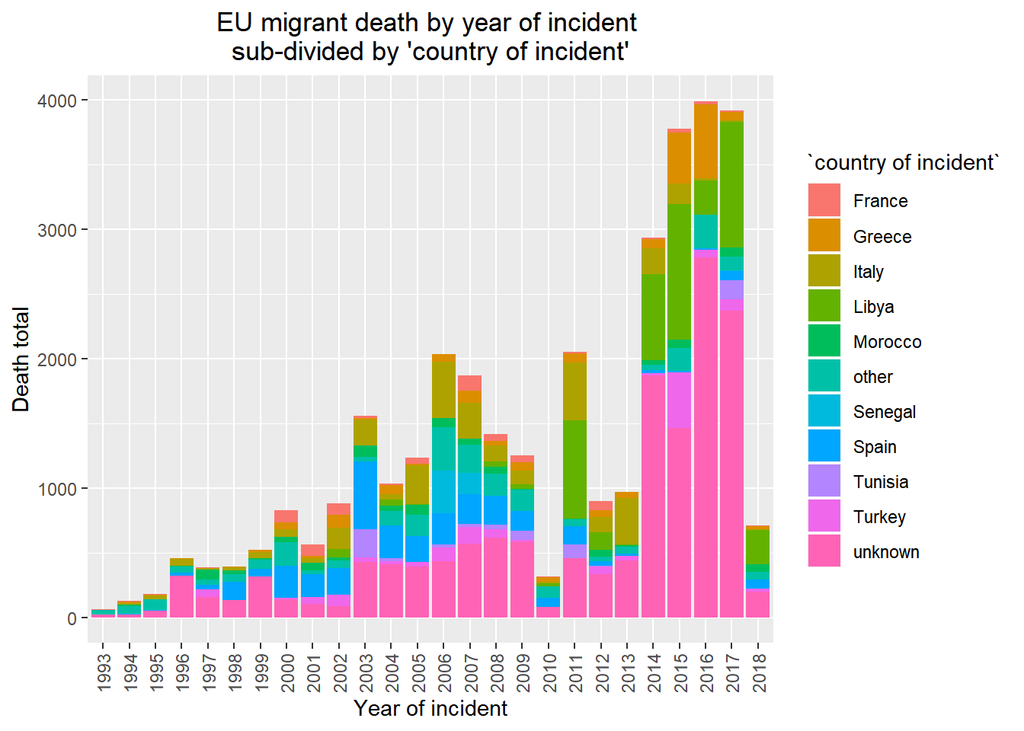

```r
#Use the data year_vs_coun_of_incident_sum

#if the total death for a country is less than n set the country to 'other'
n <- 400
year_vs_coun_of_incident_sum_other <- year_vs_coun_of_incident_sum
for (i in 1:dim(year_vs_coun_of_incident_sum_other)[1]) {
  if (year_vs_coun_of_incident_sum_other$deathbycoun[i] < n){
    year_vs_coun_of_incident_sum_other$`country of incident`[i] <- "other"
  }
}
ggplot(data =  year_vs_coun_of_incident_sum_other, aes(y=sum.number, x=year ,fill =`country of incident` )) +
  geom_col() +
  # coord_flip() +
   labs(y = "Death total", x = "Year of incident", title = "EU migrant death by year of incident \n sub-divided by 'country of incident' ") +
  theme(axis.text.x = element_text(angle = 90, vjust = 0.5, hjust=1), plot.title = element_text(hjust = 0.5))
```

```r
unknown_coun_of_incident <- sum(EU_migration_deaths$number[
                                EU_migration_deaths$`country of incident` == "unknown"])

print(paste("The country of incident for", unknown_coun_of_incident,
            "deaths occured between 1993-2018 is unidentified."))
```

```
## [1] "The country of incident for 14763 deaths occured between 1993-2018 is unidentified."
```

```r
#remove the data for unknown country of incident
# year_vs_coun_of_incident_sum_other <- year_vs_coun_of_incident_sum_other[(year_vs_coun_of_incident_sum_other$`country of incident` != "unknown"),]
#
# ggplot(data =  year_vs_coun_of_incident_sum_other, aes(y=sum.number, x=year ,fill =`country of incident` )) +
#   geom_col() +
#   # coord_flip() +
#    labs(y = "Death total", x = "Year of incident", title = "Death by year of incident \n (excluding 'unkown' country of incident)") + theme(axis.text.x = element_text(angle = 90, vjust = 0.5, hjust=1), plot.title = element_text(hjust = 0.5))
```

Plot total death vs country of incident

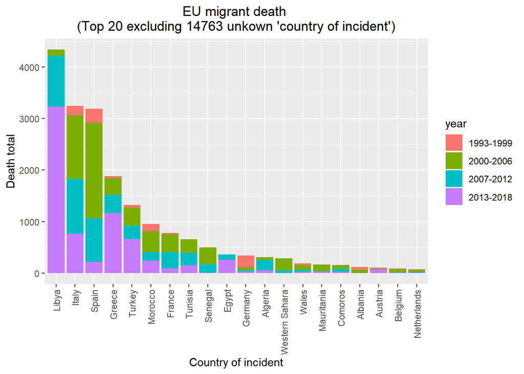

```r
#Use the data year_vs_coun_of_incident_sum
#prepare the data for total death greater than n
n<- 70

year_vs_coun_of_incident_sum_gt_n <- year_vs_coun_of_incident_sum[year_vs_coun_of_incident_sum$deathbycoun > n,]

#remove the data for unknown country of incident
year_vs_coun_of_incident_sum_gt_n <- year_vs_coun_of_incident_sum_gt_n[(year_vs_coun_of_incident_sum_gt_n$`country of incident` != "unknown"),]

for (i in 1:dim(year_vs_coun_of_incident_sum_gt_n)[1]) {
  if (year_vs_coun_of_incident_sum_gt_n$year[i] %in% c(1993:1999)){
    year_vs_coun_of_incident_sum_gt_n$year[i] <- "1993-1999"
  } else if (year_vs_coun_of_incident_sum_gt_n$year[i] %in% c(2000:2006)){
    year_vs_coun_of_incident_sum_gt_n$year[i] <- "2000-2006"
  } else if (year_vs_coun_of_incident_sum_gt_n$year[i] %in% c(2007:2012)){
    year_vs_coun_of_incident_sum_gt_n$year[i] <- "2007-2012"
  } else if (year_vs_coun_of_incident_sum_gt_n$year[i] %in% c(2013:2018)){
    year_vs_coun_of_incident_sum_gt_n$year[i] <- "2013-2018"
  }
}

ggplot(data =  year_vs_coun_of_incident_sum_gt_n, aes(y=sum.number, x=reorder(`country of incident`,desc(deathbycoun)) ,fill =year )) +
  geom_col() +
  # coord_flip() +
   labs(y = "Death total", x = "Country of incident", title = "EU migrant death \n(Top 20 excluding 14763 unkown 'country of incident')") + theme(axis.text.x = element_text(angle = 90, vjust = 0.5, hjust=1),plot.title = element_text(hjust = 0.5))
```

# Analysis by region of origin and year

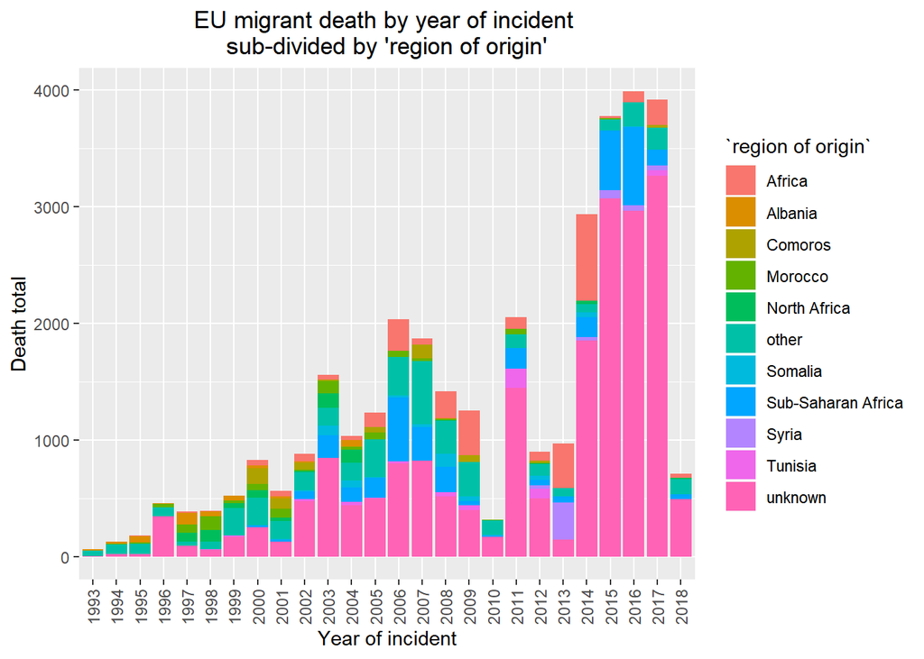

```r
library(plyr)
year_vs_region_of_origin <- ddply(EU_migration_deaths,.(year,`region of origin` ),summarize,sum.number=sum(number))

regionoforigin <- tapply(year_vs_region_of_origin$sum.number,year_vs_region_of_origin$`region of origin` , sum)

region.of.origin <- data.frame(country = names(regionoforigin))

for (i in 1:dim(region.of.origin)[1]) {region.of.origin$deathbycoun[i] <- regionoforigin[i]
}
colnames(region.of.origin)[1] <- "region of origin"
year_vs_region_of_origin_sum <- merge(year_vs_region_of_origin, region.of.origin, by= "region of origin", all.x = T )


#if the total death for a Region of origin is less than n set the region of origin to 'other'
n <- 350
year_vs_region_of_origin_sum_other <- year_vs_region_of_origin_sum
for (i in 1:dim(year_vs_region_of_origin_sum_other)[1]) {
  if (year_vs_region_of_origin_sum_other$deathbycoun[i] < n){
    year_vs_region_of_origin_sum_other$`region of origin`[i] <- "other"
  }
}
ggplot(data =  year_vs_region_of_origin_sum_other, aes(y=sum.number, x=year ,fill =`region of origin` )) +
  geom_col() +
  # coord_flip() +
   labs(y = "Death total", x = "Year of incident", title = "EU migrant death by year of incident \n sub-divided by 'region of origin' ") +
  theme(axis.text.x = element_text(angle = 90, vjust = 0.5, hjust=1), plot.title = element_text(hjust = 0.5))
```

```r
unknown_regionofinc <- sum(EU_migration_deaths$number[
                                EU_migration_deaths$`region of origin` == "unknown"])

print(paste("The 'Region of origin' for", unknown_regionofinc,
            "deaths occured between 1993-2018 is unknown."))
```

```
## [1] "The 'Region of origin' for 19773 deaths occured between 1993-2018 is unknown."
```

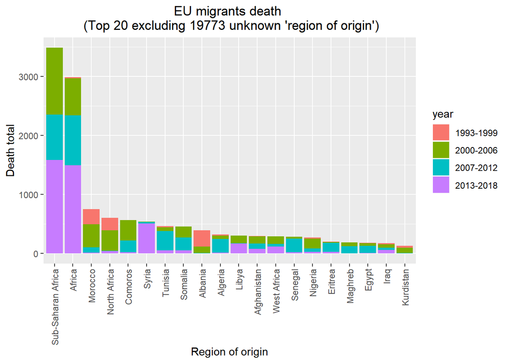

```r
#Get the data for total death greater than n
n <- 110
year_vs_region_of_origin_sum_gt_n <- year_vs_region_of_origin_sum[year_vs_region_of_origin_sum$deathbycoun > n , ]

year_vs_region_of_origin_sum_gt_n <- year_vs_region_of_origin_sum_gt_n[year_vs_region_of_origin_sum_gt_n$`region of origin` != "unknown",]

for (i in 1:dim(year_vs_region_of_origin_sum_gt_n)[1]) {
  if (year_vs_region_of_origin_sum_gt_n$year[i] %in% c(1993:1999)){
    year_vs_region_of_origin_sum_gt_n$year[i] <- "1993-1999"
  } else if (year_vs_region_of_origin_sum_gt_n$year[i] %in% c(2000:2006)){
    year_vs_region_of_origin_sum_gt_n$year[i] <- "2000-2006"
  } else if (year_vs_region_of_origin_sum_gt_n$year[i] %in% c(2007:2012)){
    year_vs_region_of_origin_sum_gt_n$year[i] <- "2007-2012"
  } else if (year_vs_region_of_origin_sum_gt_n$year[i] %in% c(2013:2018)){
    year_vs_region_of_origin_sum_gt_n$year[i] <- "2013-2018"
  }
}

ggplot(data =  year_vs_region_of_origin_sum_gt_n, aes(y=sum.number, x=reorder(`region of origin`, desc(deathbycoun)) ,fill =year )) +
  geom_col() +
  # coord_flip() +
   labs(y = "Death total", x = "Region of origin", title = "EU migrants death \n (Top 20 excluding 19773 unknown 'region of origin')") + theme(axis.text.x = element_text(angle = 90, vjust = 0.5, hjust=1), plot.title = element_text(hjust = 0.5))
```

# Analysis by cause of death and year

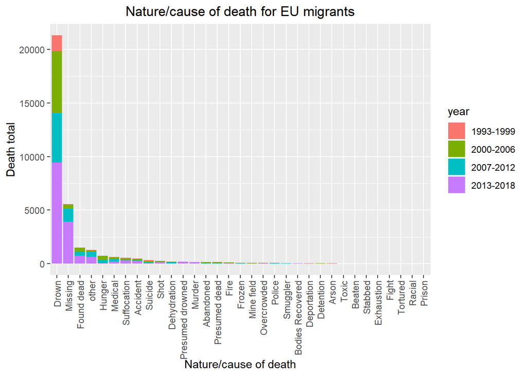

```r
library(plyr)
year_vs_nature_of_death <- ddply(EU_migration_deaths,.(year,`Nature of death` ),summarize,sum.number=sum(number))

natureofdeath <- tapply(year_vs_nature_of_death$sum.number,year_vs_nature_of_death$`Nature of death` , sum)

nature.of.death <- data.frame(country = names(natureofdeath))

for (i in 1:dim(nature.of.death)[1]) {nature.of.death$deathbynature[i] <- natureofdeath[i]
}
colnames(nature.of.death)[1] <- "Nature of death"
year_vs_nature_of_death_sum <- merge(year_vs_nature_of_death, nature.of.death, by= "Nature of death", all.x = T )

for (i in 1:dim(year_vs_nature_of_death_sum)[1]) {
  if (year_vs_nature_of_death_sum$year[i] %in% c(1993:1999)){
    year_vs_nature_of_death_sum$year[i] <- "1993-1999"
  } else if (year_vs_nature_of_death_sum$year[i] %in% c(2000:2006)){
    year_vs_nature_of_death_sum$year[i] <- "2000-2006"
  } else if (year_vs_nature_of_death_sum$year[i] %in% c(2007:2012)){
    year_vs_nature_of_death_sum$year[i] <- "2007-2012"
  } else if (year_vs_nature_of_death_sum$year[i] %in% c(2013:2018)){
    year_vs_nature_of_death_sum$year[i] <- "2013-2018"
  }
}

prop_drown <- sum(year_vs_nature_of_death$sum.number[year_vs_nature_of_death$`Nature of death` =='Drown'])/sum(year_vs_nature_of_death$sum.number)

prop_missing <- sum(year_vs_nature_of_death$sum.number[year_vs_nature_of_death$`Nature of death` =='Missing'])/sum(year_vs_nature_of_death$sum.number)

prop_found_dead <- sum(year_vs_nature_of_death$sum.number[year_vs_nature_of_death$`Nature of death` =='Found dead'])/sum(year_vs_nature_of_death$sum.number)

prop_other <- sum(year_vs_nature_of_death$sum.number[year_vs_nature_of_death$`Nature of death` =='other'])/sum(year_vs_nature_of_death$sum.number)

ggplot(data =  year_vs_nature_of_death_sum, aes(y=sum.number, x=reorder(`Nature of death`, desc(deathbynature)) ,fill =year )) +
  geom_col() +
  # coord_flip() +
   labs(y = "Death total", x = "Nature/cause of death", title = "Nature/cause of death for EU migrants") + theme(axis.text.x = element_text(angle = 90, vjust = 0.5, hjust=1), plot.title = element_text(hjust = 0.5))
```

The proportions of death caused by “Drowning” ,“Missing”, “Found dead” and “other” are: 0.6203, 0.1614, 0.0441 and 0.0377 respectively.

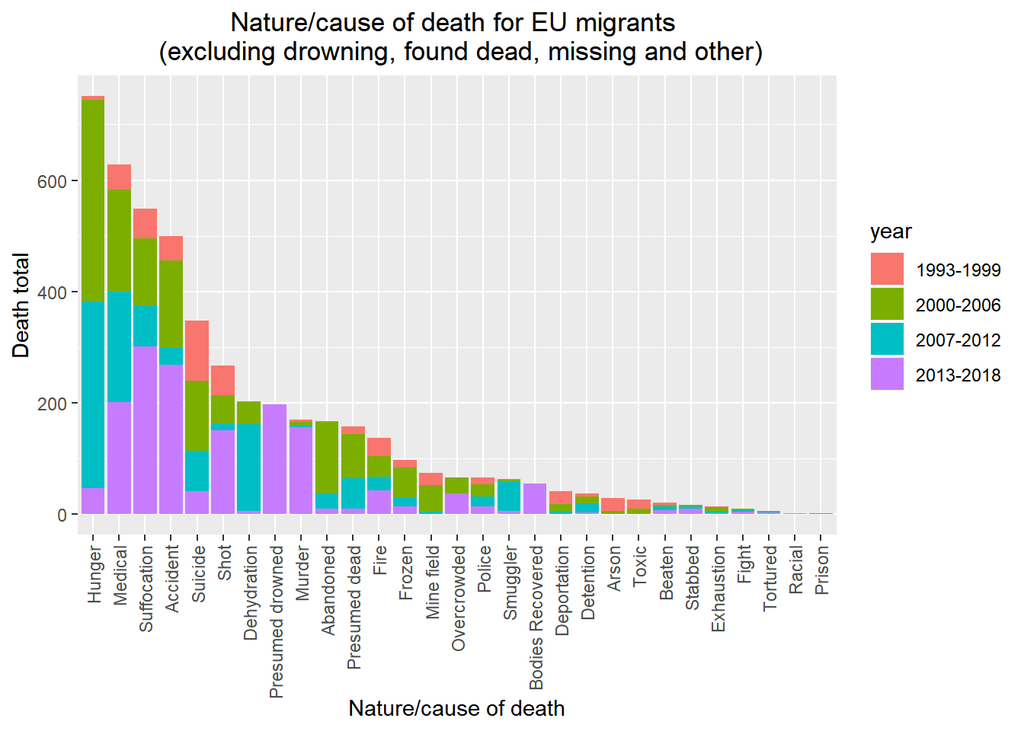

```r
#Death by nature of death excluding drowning, found dead, missing and other:

year_vs_nature_of_death_sum_trimmed <- year_vs_nature_of_death_sum[
                              (year_vs_nature_of_death_sum$`Nature of death` != "Drown") &
                              (year_vs_nature_of_death_sum$`Nature of death` != "Missing") &
                              (year_vs_nature_of_death_sum$`Nature of death` != "Found dead") &
                              (year_vs_nature_of_death_sum$`Nature of death` != "other"),]

ggplot(data =  year_vs_nature_of_death_sum_trimmed, aes(y=sum.number, x=reorder(`Nature of death`, desc(deathbynature)) ,fill =year )) +
  geom_col() +
  # coord_flip() +
   labs(y = "Death total", x = "Nature/cause of death", title = "Nature/cause of death for EU migrants \n (excluding drowning, found dead, missing and other)") + theme(axis.text.x = element_text(angle = 90, vjust = 0.5, hjust=1), plot.title = element_text(hjust = 0.5))
```

There is a recent surge in death count in last five years for the deaths caused by suffocation, accident, shooting and murder.

Analysis for the path of migration for the deaths caused by drowning or presumed drowning:

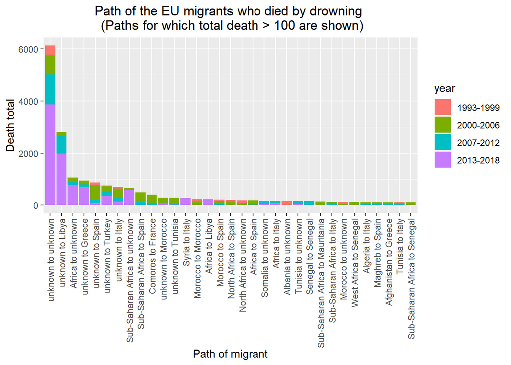

```r
#get the data for nature of death = Drown

data_drown <- EU_migration_deaths[((EU_migration_deaths$`Nature of death`=="Drown") |
                                     (EU_migration_deaths$`Nature of death`=="Presumed drowned")),]

library(plyr)
data_drown_by_pathandyear <- ddply(data_drown,.(year,Path), summarize, sum.number=sum(number))

bypath <- tapply(data_drown_by_pathandyear$sum.number,data_drown_by_pathandyear$Path , sum)

by.path <- data.frame(Path = names(bypath))

for (i in 1:dim(by.path)[1]) {by.path$deathbypath[i] <- bypath[i]
}

data_drown_by_pathandyear_sum <- merge(data_drown_by_pathandyear, by.path, by= "Path", all.x = T )

for (i in 1:dim(data_drown_by_pathandyear_sum)[1]) {
  if (data_drown_by_pathandyear_sum$year[i] %in% c(1993:1999)){
    data_drown_by_pathandyear_sum$year[i] <- "1993-1999"
  } else if (data_drown_by_pathandyear_sum$year[i] %in% c(2000:2006)){
    data_drown_by_pathandyear_sum$year[i] <- "2000-2006"
  } else if (data_drown_by_pathandyear_sum$year[i] %in% c(2007:2012)){
    data_drown_by_pathandyear_sum$year[i] <- "2007-2012"
  } else if (data_drown_by_pathandyear_sum$year[i] %in% c(2013:2018)){
    data_drown_by_pathandyear_sum$year[i] <- "2013-2018"
  }
}


#prepare the data for total death by path greater than n
n<- 100

data_drown_by_pathandyear_sum_gtn <- data_drown_by_pathandyear_sum[data_drown_by_pathandyear_sum$deathbypath > n,]



ggplot(data =  data_drown_by_pathandyear_sum_gtn, aes(y=sum.number, x=reorder(Path, desc(deathbypath)) ,fill =year )) +
  geom_col() +
  # coord_flip() +
   labs(y = "Death total", x = "Path of migrant", title = "Path of the EU migrants who died by drowning \n (Paths for which total death > 100 are shown)") + theme(axis.text.x = element_text(angle = 90, vjust = 0.5, hjust=1), plot.title = element_text(hjust = 0.5))
```

```r
print("There is a huge number of death caused by drowning for which the 'region of origin' and/or 'country of incident' are unknown.")
```

```
## [1] "There is a huge number of death caused by drowning for which the 'region of origin' and/or 'country of incident' are unknown."
```

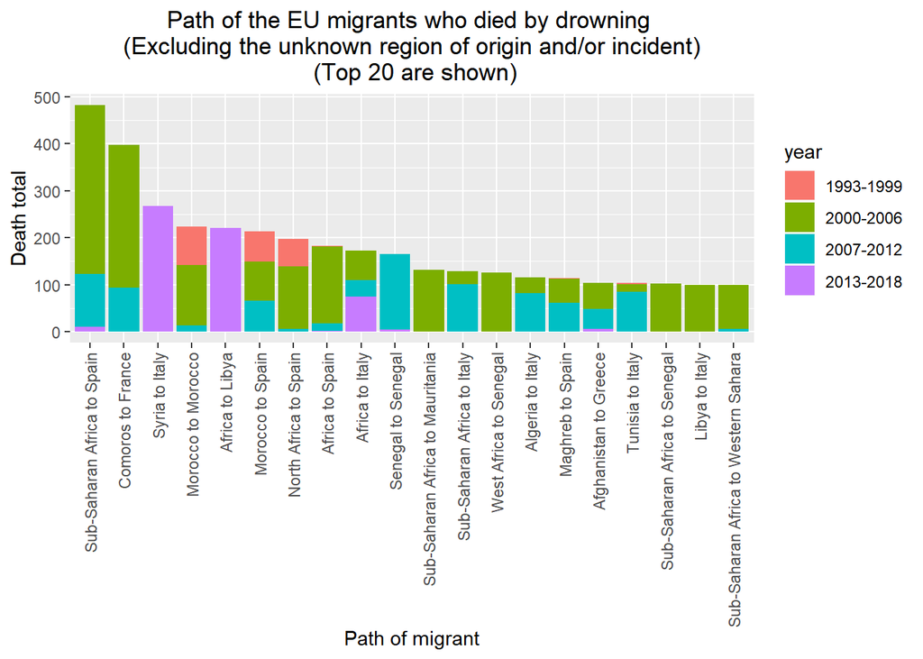

```r
#Exclude unknown paths:
data_drown_by_pathandyear_sum_ex <- data_drown_by_pathandyear_sum[
                          grepl("unknown",data_drown_by_pathandyear_sum$Path)== F,]
#plot for deathby path > n
n<- 95

data_drown_by_pathandyear_sum_ex <- data_drown_by_pathandyear_sum_ex[data_drown_by_pathandyear_sum_ex$deathbypath > n,]



ggplot(data =  data_drown_by_pathandyear_sum_ex, aes(y=sum.number, x=reorder(Path, desc(deathbypath)) ,fill =year )) +
  geom_col() +
  # coord_flip() +
   labs(y = "Death total", x = "Path of migrant", title = "Path of the EU migrants who died by drowning \n (Excluding the unknown region of origin and/or incident) \n (Top 20 are shown)") + theme(axis.text.x = element_text(angle = 90, vjust = 0.5, hjust=1), plot.title = element_text(hjust = 0.5))
```